# Fort Pickens State Park Aquatic Preserve

SEACAR Water Quality Analysis

Last compiled on 15 July, 2026

# Indicators

## Nutrients

### Total Nitrogen - Discrete

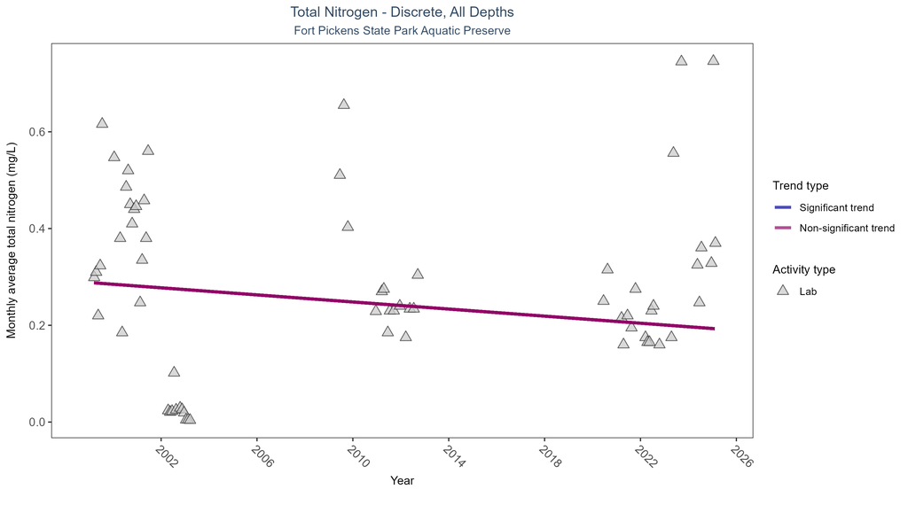

Scatter plot of monthly average total nitrogen over time. If the time series included ten or more years of discrete observations, a significant (blue) or non-significant (magenta) trend line is also shown. Only nitrogen values obtained from laboratory analyses (triangles) are included in the plot.

Table:

Total nitrogen showed no detectable trend between 1999 and 2025.

| Activity Type | Statistical Trend | Sample Count | Years with Data | Period of Record | Median Result Value | Tau | Sen Intercept | Sen Slope | P |
| --- | --- | --- | --- | --- | --- | --- | --- | --- | --- |
| Lab | No detectable trend | 119 | 15 | 1999 - 2025 | 0.245 | -0.08647 | 0.28849 | -0.00366 | 0.3742 |

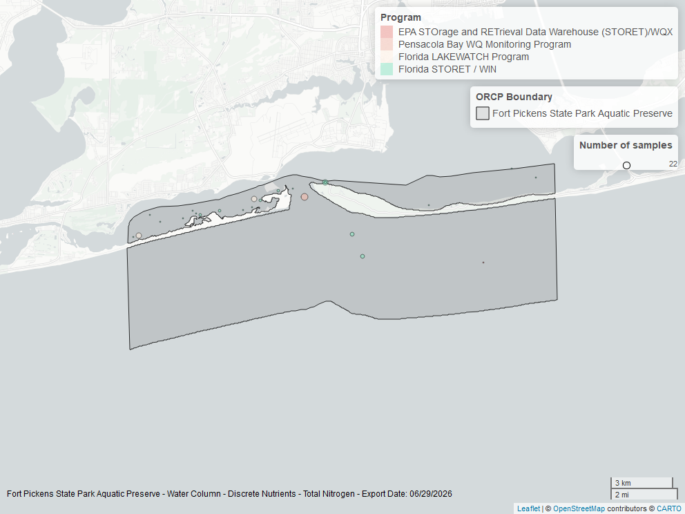

Map showing location of discrete water quality sampling locations within the boundaries of *Fort Pickens State Park Aquatic Preserve*. The bubble size on the maps above reflect the amount of data available at each sampling site.

### Total Phosphorus - Discrete

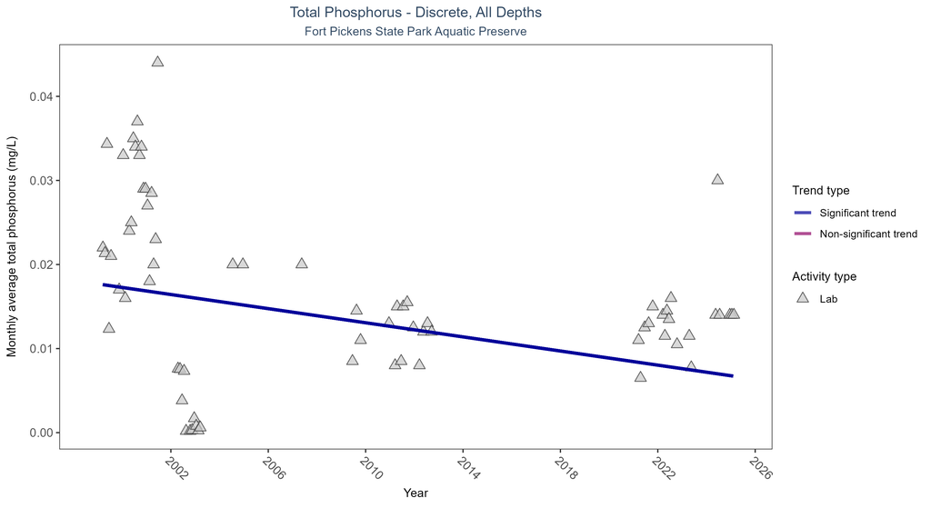

Scatter plot of monthly average total phosphorus over time. If the time series included ten or more years of discrete observations, a significant (blue) or non-significant (magenta) trend line is also shown. Only phosphorus values obtained from laboratory analyses (triangles) are included in the plot.

Table:

Monthly average total phosphorus decreased by less than 0.01 mg/L per year.

| Activity Type | Statistical Trend | Sample Count | Years with Data | Period of Record | Median Result Value | Tau | Sen Intercept | Sen Slope | P |
| --- | --- | --- | --- | --- | --- | --- | --- | --- | --- |
| Lab | Decreasing trend | 118 | 16 | 1999 - 2025 | 0.0135 | -0.32037 | 0.01769 | -0.00042 | 0.0072 |

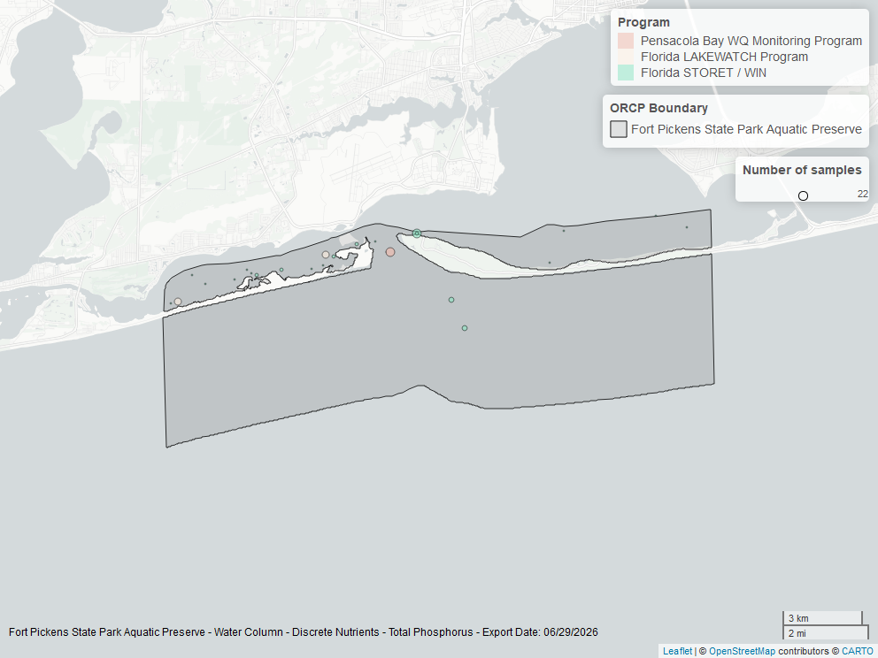

Map showing location of discrete water quality sampling locations within the boundaries of *Fort Pickens State Park Aquatic Preserve*. The bubble size on the maps above reflect the amount of data available at each sampling site.

## Water Quality

### Dissolved Oxygen - Continuous

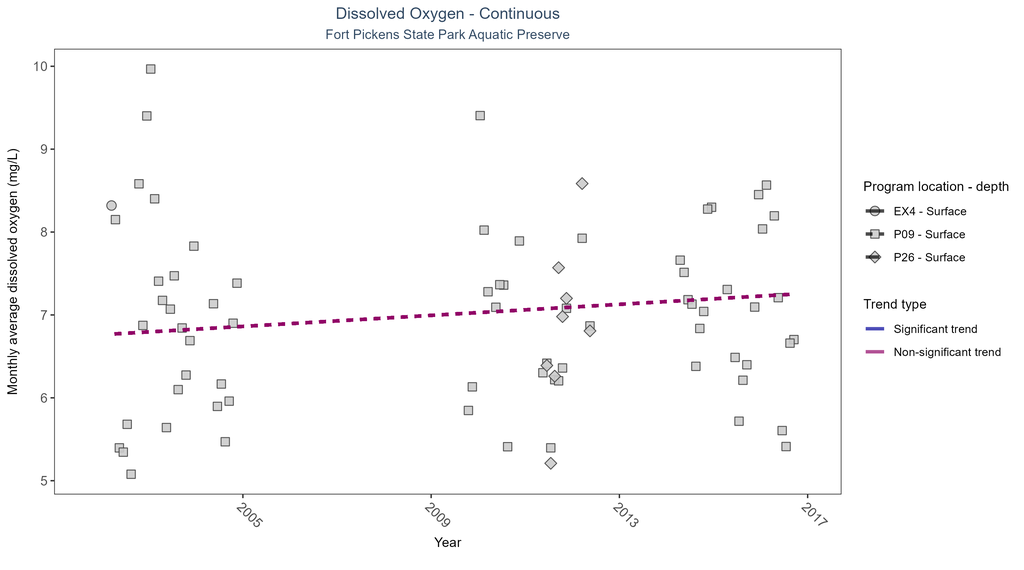

Scatter plot of monthly average dissolved oxygen over time at continuously monitored program locations. Each location is analyzed separately, with significant (blue) or non-significant (magenta) trend lines shown for time series that included five or more years of observations.

Table:

No detectable change in monthly average dissolved oxygen was observed at one location. There was insufficient data to fit a model for two locations.

| Program Location | Statistical Trend | Sample Count | Years with Data | Period of Record | Median Result Value | Tau | Sen Intercept | Sen Slope | P |
| --- | --- | --- | --- | --- | --- | --- | --- | --- | --- |
| EX4 | Insufficient data | 2 | 1 | 2002 - 2002 | 8.32 | - | - | - | - |
| P09 | No detectable trend | 364 | 10 | 2002 - 2016 | 6.82 | 0.14 | 6.76 | 0.03 | 0.1 |
| P26 | Insufficient data | 27 | 2 | 2011 - 2012 | 6.61 | - | - | - | - |

[figure not shown]

Map showing location of dissolved oxygen continuous water quality sampling locations within the boundaries of *Fort Pickens State Park Aquatic Preserve*. The bubble size on the maps above reflect the amount of data available at each sampling site.

### Dissolved Oxygen - Discrete

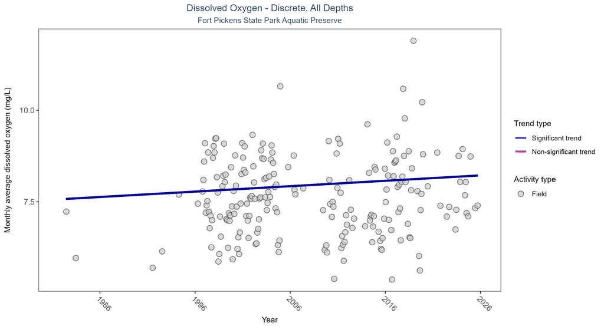

Scatter plot of monthly average dissolved oxygen over time. If the time series included ten or more years of discrete observations, a significant (blue) or non-significant (magenta) trend line is also shown. Only dissolved oxygen values measured in the field (circles) are included in the plot.

Table:

Monthly average dissolved oxygen increased by 0.01 mg/L per year.

| Activity Type | Statistical Trend | Sample Count | Years with Data | Period of Record | Median Result Value | Tau | Sen Intercept | Sen Slope | P |
| --- | --- | --- | --- | --- | --- | --- | --- | --- | --- |
| Field | Increasing trend | 1212 | 34 | 1982 - 2025 | 7.505 | 0.1119 | 7.57427 | 0.01475 | 0.0193 |

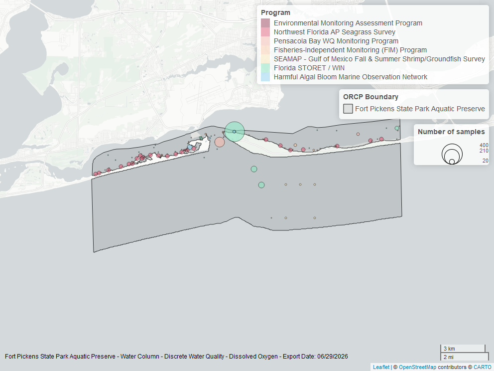

Map showing location of discrete water quality sampling locations within the boundaries of *Fort Pickens State Park Aquatic Preserve*. The bubble size on the maps above reflect the amount of data available at each sampling site.

### Dissolved Oxygen Saturation - Continuous

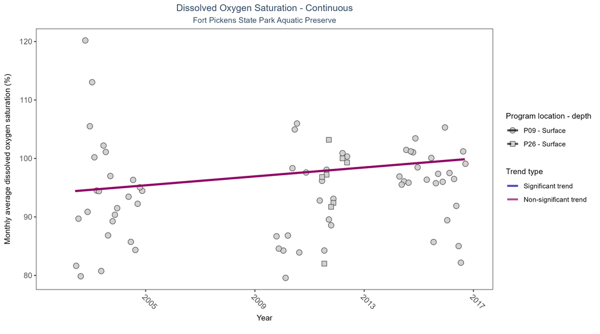

Scatter plot of monthly average dissolved oxygen saturation over time at continuously monitored program locations. Each location is analyzed separately, with significant (blue) or non-significant (magenta) trend lines shown for time series that included five or more years of observations.

Table:

No detectable change in monthly average dissolved oxygen saturation was observed at one location. There was insufficient data to fit a model for one location.

| Program Location | Statistical Trend | Sample Count | Years with Data | Period of Record | Median Result Value | Tau | Sen Intercept | Sen Slope | P |
| --- | --- | --- | --- | --- | --- | --- | --- | --- | --- |
| P09 | No detectable trend | 358 | 10 | 2002 - 2016 | 96.91 | 0.11 | 94.26 | 0.38 | 0.24 |
| P26 | Insufficient data | 27 | 2 | 2011 - 2012 | 98.17 | - | - | - | - |

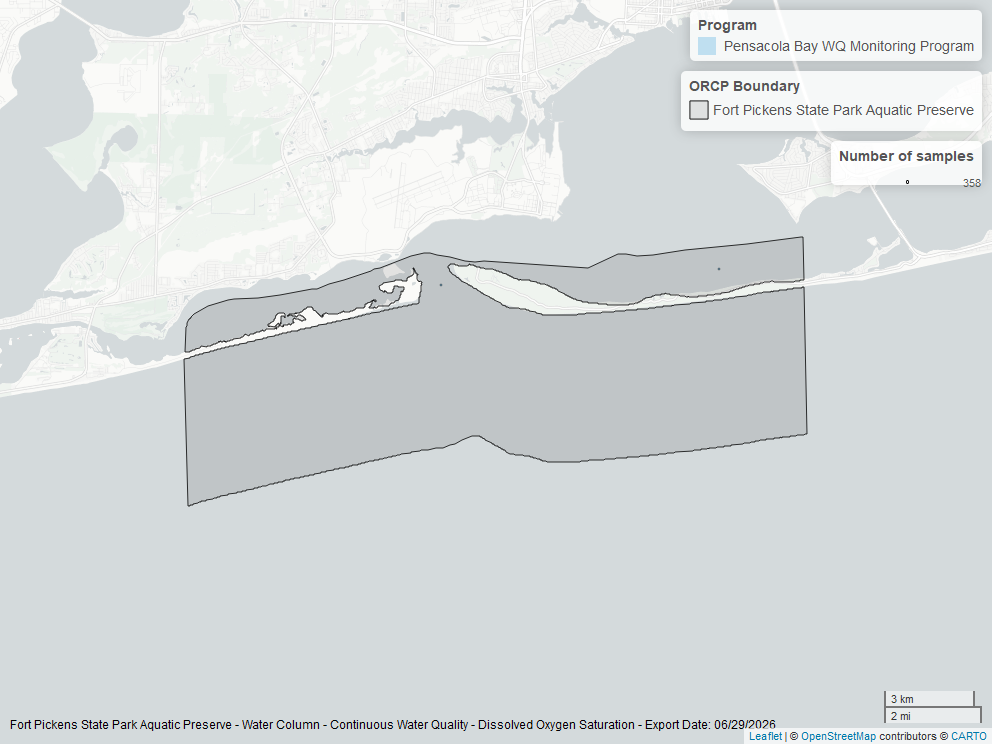

Map showing location of dissolved oxygen saturation continuous water quality sampling locations within the boundaries of *Fort Pickens State Park Aquatic Preserve*. The bubble size on the maps above reflect the amount of data available at each sampling site.

### Dissolved Oxygen Saturation - Discrete

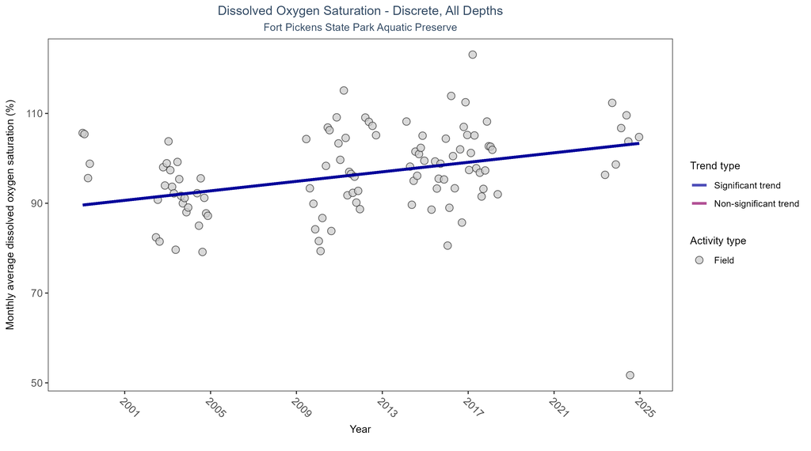

Scatter plot of monthly average dissolved oxygen saturation over time. If the time series included ten or more years of discrete observations, a significant (blue) or non-significant (magenta) trend line is also shown. Only dissolved oxygen saturation values measured in the field (circles) are included in the plot.

Table:

Monthly average dissolved oxygen saturation increased by 0.53% per year.

| Activity Type | Statistical Trend | Sample Count | Years with Data | Period of Record | Median Result Value | Tau | Sen Intercept | Sen Slope | P |
| --- | --- | --- | --- | --- | --- | --- | --- | --- | --- |
| Field | Increasing trend | 261 | 15 | 1999 - 2024 | 98.6 | 0.27656 | 89.58022 | 0.52972 | 0.0004 |

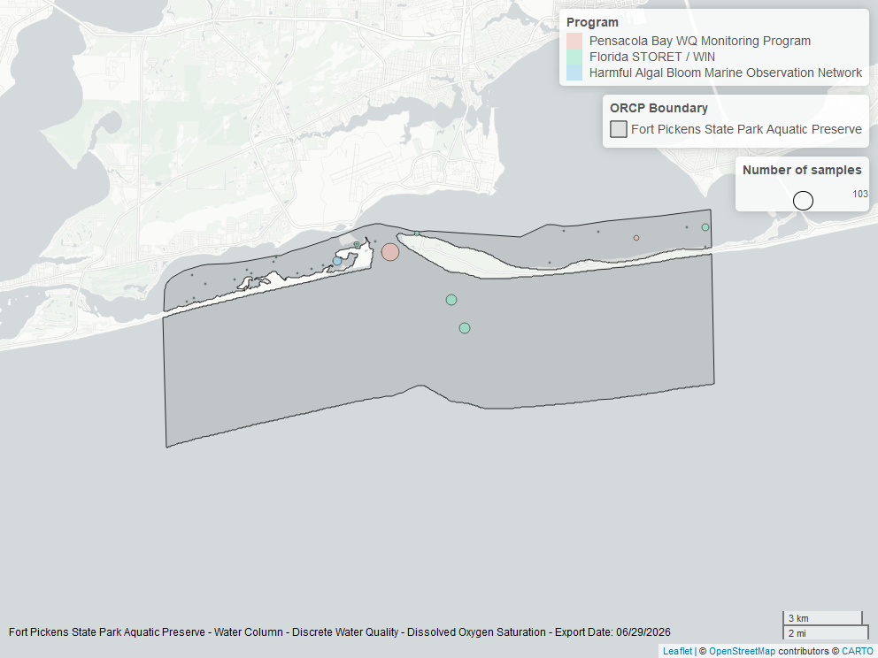

Map showing location of discrete water quality sampling locations within the boundaries of *Fort Pickens State Park Aquatic Preserve*. The bubble size on the maps above reflect the amount of data available at each sampling site.

### Salinity - Discrete

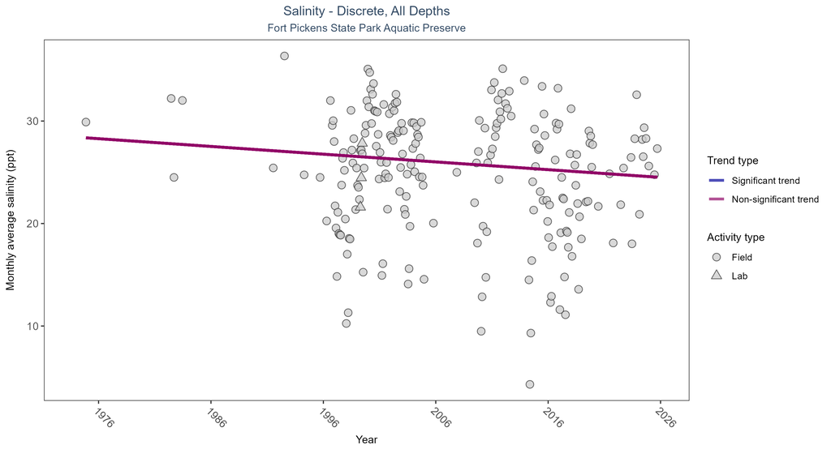

Scatter plot of monthly average salinity over time. If the time series included ten or more years of discrete observations, significant (blue) or non-significant (magenta) trend lines are also shown. Discrete salinity values derived from grab samples analyzed in the field (circles) or the laboratory (triangles) are both included in the plot.

Table:

Salinity showed no detectable trend between 1974 and 2025.

| Activity Type | Statistical Trend | Sample Count | Years with Data | Period of Record | Median Result Value | Tau | Sen Intercept | Sen Slope | P |
| --- | --- | --- | --- | --- | --- | --- | --- | --- | --- |
| All | No detectable trend | 1230 | 35 | 1974 - 2025 | 26.2 | -0.08405 | 28.42861 | -0.07554 | 0.0824 |

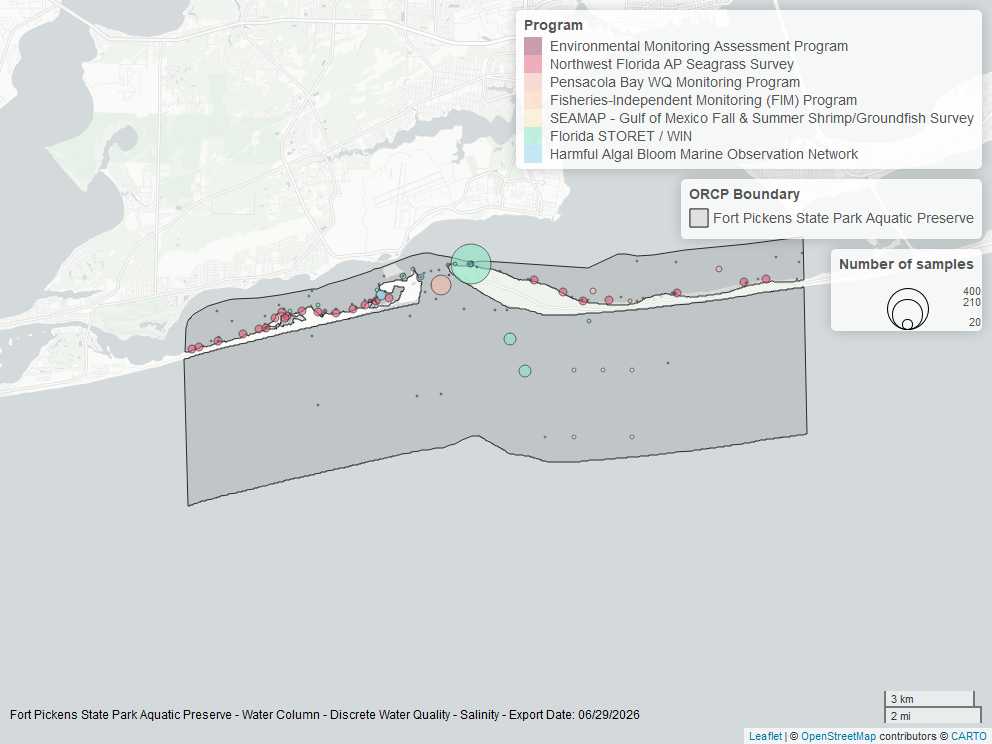

Map showing location of discrete water quality sampling locations within the boundaries of *Fort Pickens State Park Aquatic Preserve*. The bubble size on the maps above reflect the amount of data available at each sampling site.

### Salinity - Continuous

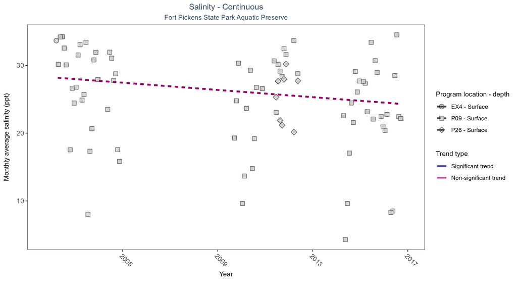

Scatter plot of monthly average salinity over time at continuously monitored program locations. Each location is analyzed separately, with significant (blue) or non-significant (magenta) trend lines shown for time series that included five or more years of observations.

Table:

No detectable change in monthly average salinity was observed at one location. There was insufficient data to fit a model for two locations.

| Program Location | Statistical Trend | Sample Count | Years with Data | Period of Record | Median Result Value | Tau | Sen Intercept | Sen Slope | P |
| --- | --- | --- | --- | --- | --- | --- | --- | --- | --- |
| EX4 | Insufficient data | 2 | 1 | 2002 - 2002 | 33.65 | - | - | - | - |
| P09 | No detectable trend | 373 | 10 | 2002 - 2016 | 25.91 | -0.17 | 28.25 | -0.27 | 0.13 |
| P26 | Insufficient data | 27 | 2 | 2011 - 2012 | 26.38 | - | - | - | - |

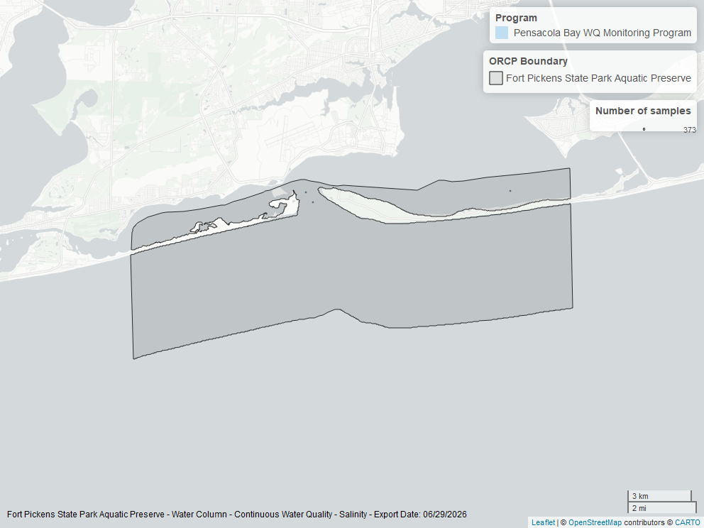

Map showing location of salinity continuous water quality sampling locations within the boundaries of *Fort Pickens State Park Aquatic Preserve*. The bubble size on the maps above reflect the amount of data available at each sampling site.

### Water Temperature - Continuous

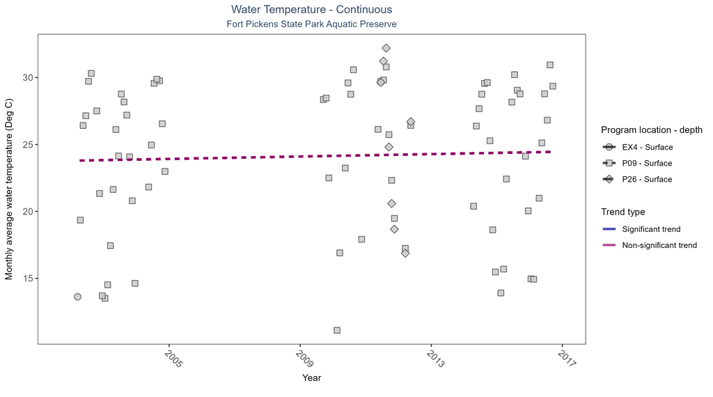

Scatter plot of monthly average water temperature over time at continuously monitored program locations. Each location is analyzed separately, with significant (blue) or non-significant (magenta) trend lines shown for time series that included five or more years of observations.

Table:

No detectable change in monthly average water temperature was observed at one location. There was insufficient data to fit a model for two locations.

| Program Location | Statistical Trend | Sample Count | Years with Data | Period of Record | Median Result Value | Tau | Sen Intercept | Sen Slope | P |
| --- | --- | --- | --- | --- | --- | --- | --- | --- | --- |
| EX4 | Insufficient data | 2 | 1 | 2002 - 2002 | 13.62 | - | - | - | - |
| P09 | No detectable trend | 373 | 10 | 2002 - 2016 | 26.39 | 0.1 | 23.79 | 0.05 | 0.45 |
| P26 | Insufficient data | 27 | 2 | 2011 - 2012 | 29.64 | - | - | - | - |

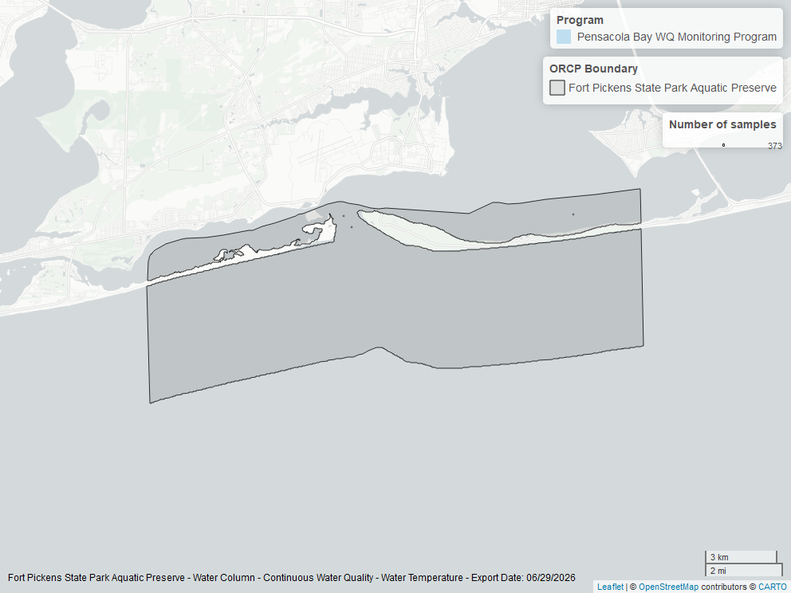

Map showing location of water temperature continuous water quality sampling locations within the boundaries of *Fort Pickens State Park Aquatic Preserve*. The bubble size on the maps above reflect the amount of data available at each sampling site.

### Water Temperature - Discrete

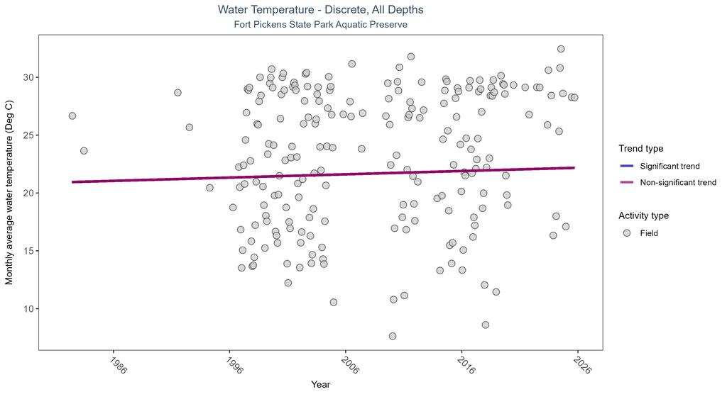

Scatter plot of monthly average water temperature over time. If the time series included ten or more years of discrete observations, a significant (blue) or non-significant (magenta) trend line is also shown. Only water temperature measurements taken in the field (circles) are included in the plot.

Table:

Water temperature showed no detectable trend between 1982 and 2025.

| Activity Type | Statistical Trend | Sample Count | Years with Data | Period of Record | Median Result Value | Tau | Sen Intercept | Sen Slope | P |
| --- | --- | --- | --- | --- | --- | --- | --- | --- | --- |
| Field | No detectable trend | 1238 | 34 | 1982 - 2025 | 27.4 | 0.08193 | 20.9339 | 0.02836 | 0.0517 |

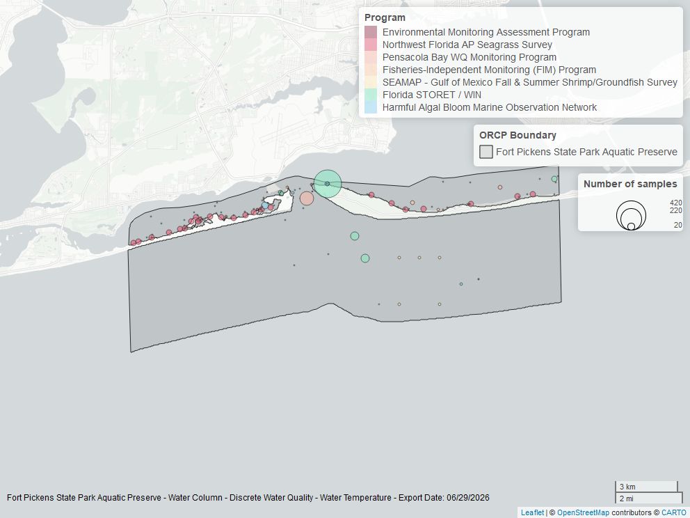

Map showing location of discrete water quality sampling locations within the boundaries of *Fort Pickens State Park Aquatic Preserve*. The bubble size on the maps above reflect the amount of data available at each sampling site.

### pH - Continuous

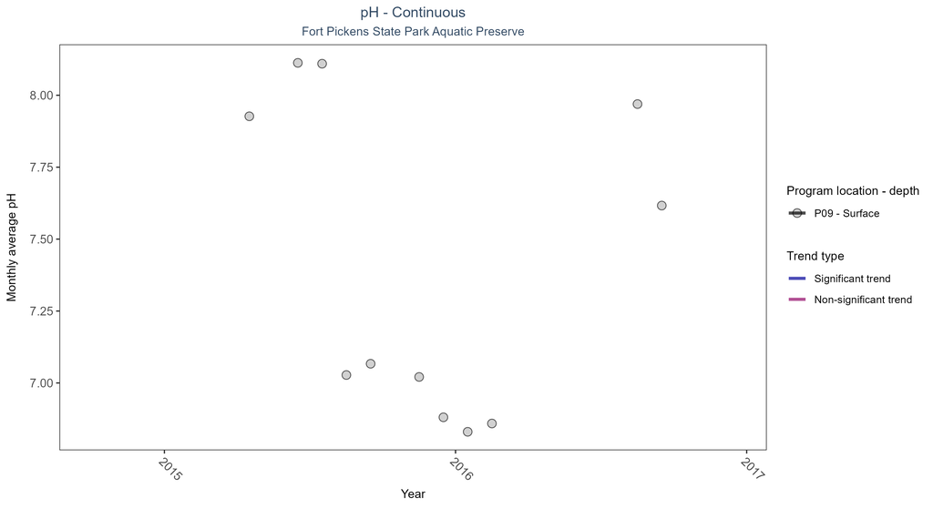

Scatter plot of monthly average pH over time at continuously monitored program locations. Each location is analyzed separately, with significant (blue) or non-significant (magenta) trend lines shown for time series that included five or more years of observations.

Table:

There was insufficient data to fit a model for one location.

| Program Location | Statistical Trend | Sample Count | Years with Data | Period of Record | Median Result Value | Tau | Sen Intercept | Sen Slope | P |
| --- | --- | --- | --- | --- | --- | --- | --- | --- | --- |
| P09 | Insufficient data | 157 | 2 | 2015 - 2016 | 7.06 | - | - | - | - |

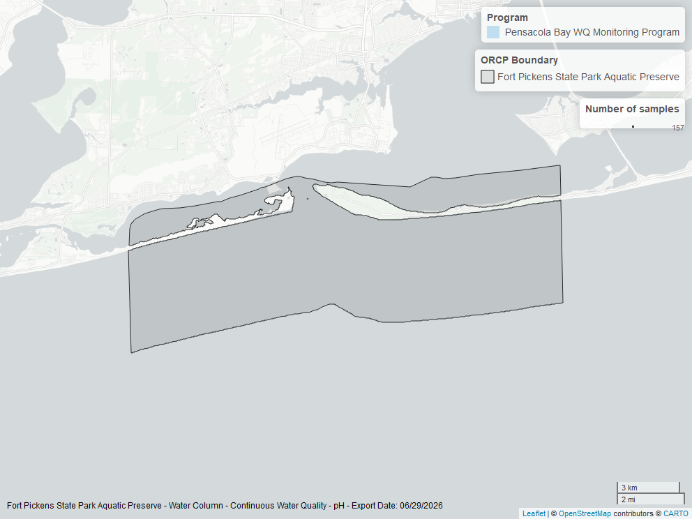

Map showing location of ph continuous water quality sampling locations within the boundaries of *Fort Pickens State Park Aquatic Preserve*. The bubble size on the maps above reflect the amount of data available at each sampling site.

### pH - Discrete

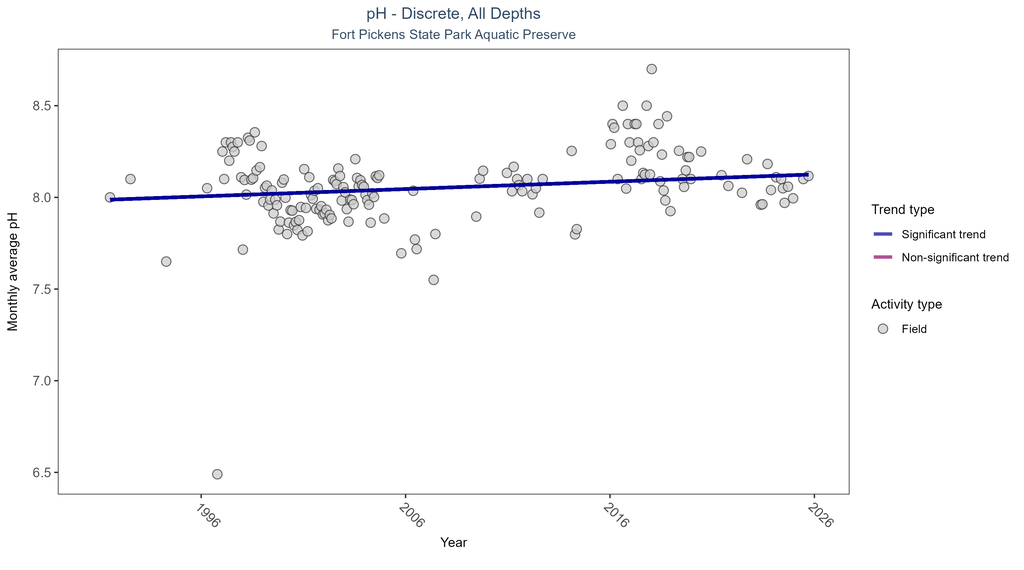

Scatter plot of monthly average pH over time. If the time series included ten or more years of discrete observations, a significant (blue) or non-significant (magenta) trend line is also shown. Only pH values measured in the field (circles) are included in the plot.

Table:

Monthly average pH increased by less than 0.01 pH units per year.

| Activity Type | Statistical Trend | Sample Count | Years with Data | Period of Record | Median Result Value | Tau | Sen Intercept | Sen Slope | P |
| --- | --- | --- | --- | --- | --- | --- | --- | --- | --- |
| Field | Increasing trend | 1003 | 30 | 1991 - 2025 | 8.1 | 0.17298 | 7.98539 | 0.004 | 0.0077 |

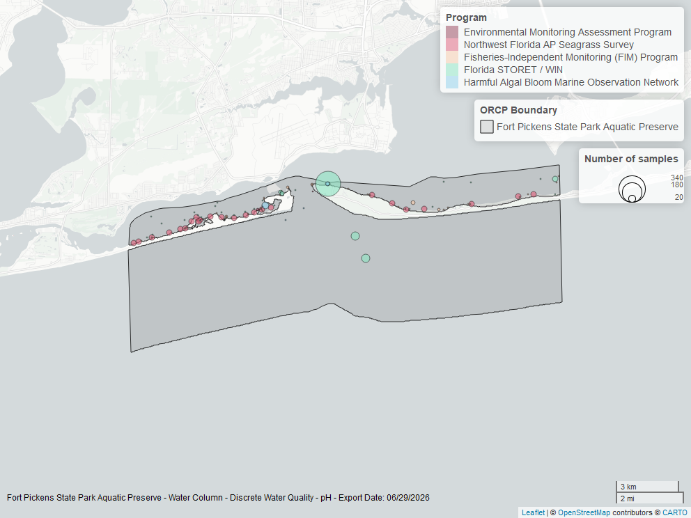

Map showing location of discrete water quality sampling locations within the boundaries of *Fort Pickens State Park Aquatic Preserve*. The bubble size on the maps above reflect the amount of data available at each sampling site.

## Water Clarity

### Turbidity - Continuous

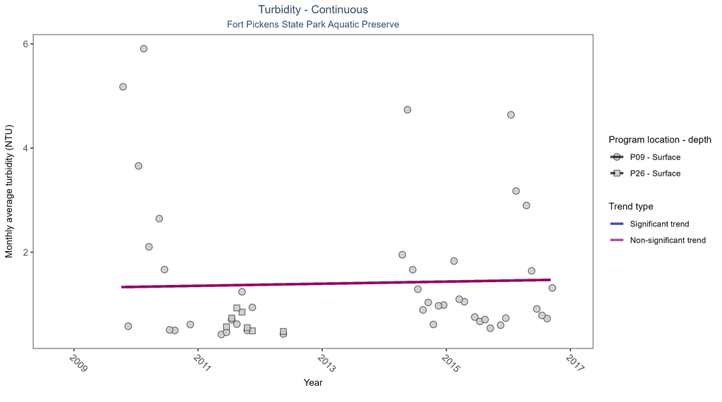

Scatter plot of monthly average turbidity over time at continuously monitored program locations. Each location is analyzed separately, with significant (blue) or non-significant (magenta) trend lines shown for time series that included five or more years of observations.

Table:

No detectable change in monthly average turbidity was observed at one location. There was insufficient data to fit a model for one location.

| Program Location | Statistical Trend | Sample Count | Years with Data | Period of Record | Median Result Value | Tau | Sen Intercept | Sen Slope | P |
| --- | --- | --- | --- | --- | --- | --- | --- | --- | --- |
| P09 | No detectable trend | 275 | 7 | 2009 - 2016 | 0.85 | 0.07 | 1.31 | 0.02 | 0.38 |
| P26 | Insufficient data | 25 | 2 | 2011 - 2012 | 0.62 | - | - | - | - |

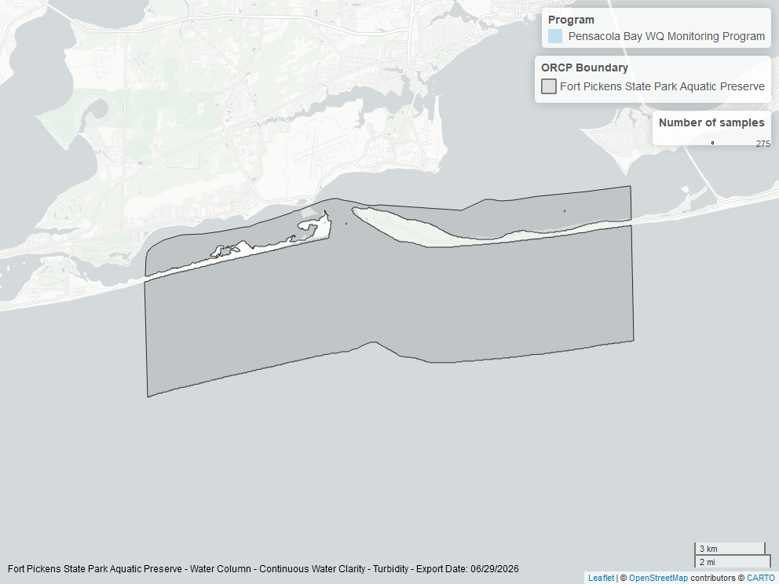

Map showing location of turbidity continuous water quality sampling locations within the boundaries of *Fort Pickens State Park Aquatic Preserve*. The bubble size on the maps above reflect the amount of data available at each sampling site.

### Turbidity - Discrete

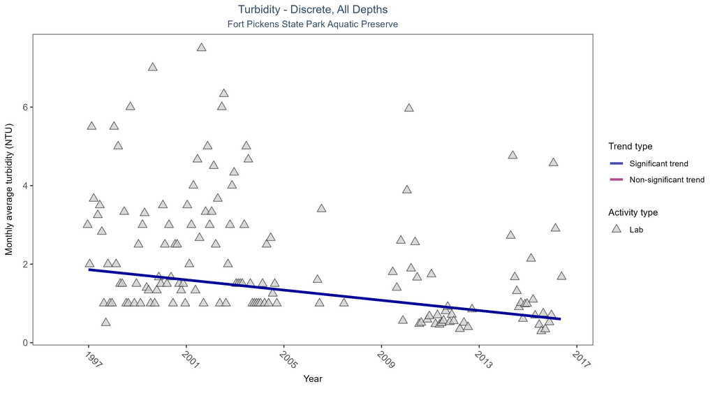

Scatter plot of monthly average turbidity over time. If the time series included ten or more years of discrete observations, a significant (blue) or non-significant (magenta) trend line is also shown. Only turbidity values measured in the laboratory (triangles) are included in the plot.

Table:

Monthly average turbidity decreased by 0.07 NTU per year, indicating an increase in water clarity.

| Activity Type | Statistical Trend | Sample Count | Years with Data | Period of Record | Median Result Value | Tau | Sen Intercept | Sen Slope | P |
| --- | --- | --- | --- | --- | --- | --- | --- | --- | --- |
| Lab | Decreasing trend | 313 | 18 | 1996 - 2016 | 1.0122 | -0.31425 | 1.92558 | -0.06511 | 0 |

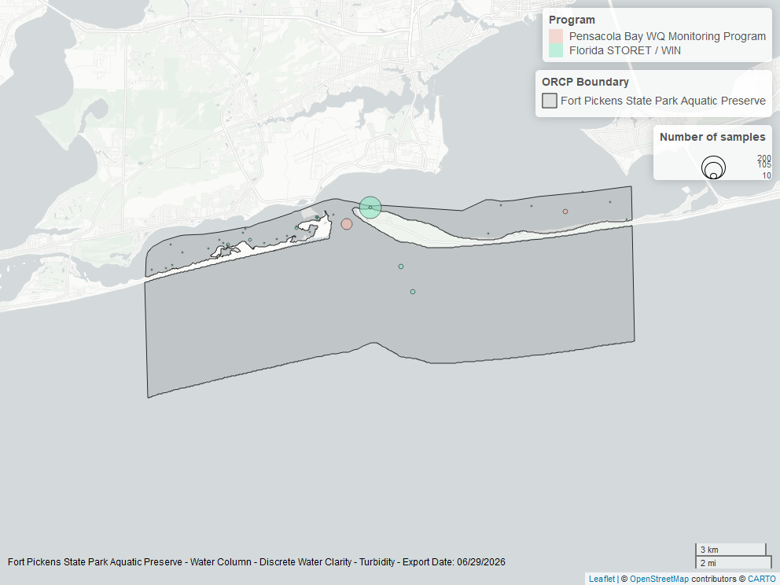

Map showing location of discrete water quality sampling locations within the boundaries of *Fort Pickens State Park Aquatic Preserve*. The bubble size on the maps above reflect the amount of data available at each sampling site.

### Total Suspended Solids - Discrete

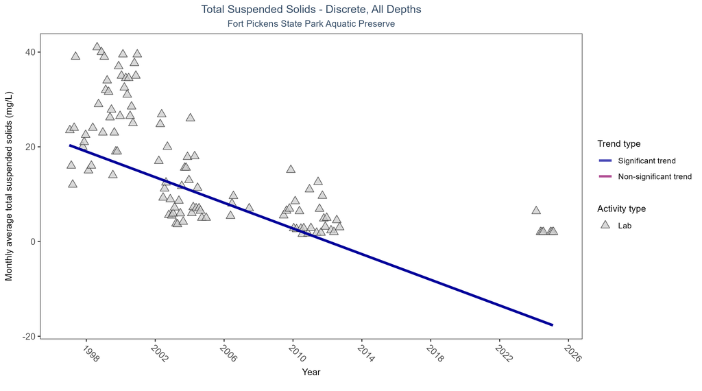

Scatter plot of monthly average total suspended solids (TSS) over time. If the time series included ten or more years of discrete observations, a significant (blue) or non-significant (magenta) trend line is also shown. Only TSS values obtained from laboratory analyses (triangles) are included in the plot.

Table:

Monthly average total suspended solids decreased by 1.35 mg/L per year, indicating an increase in water clarity.

| Activity Type | Statistical Trend | Sample Count | Years with Data | Period of Record | Median Result Value | Tau | Sen Intercept | Sen Slope | P |
| --- | --- | --- | --- | --- | --- | --- | --- | --- | --- |
| Lab | Decreasing trend | 264 | 15 | 1997 - 2025 | 9.2 | -0.63671 | 20.36003 | -1.35417 | 0 |

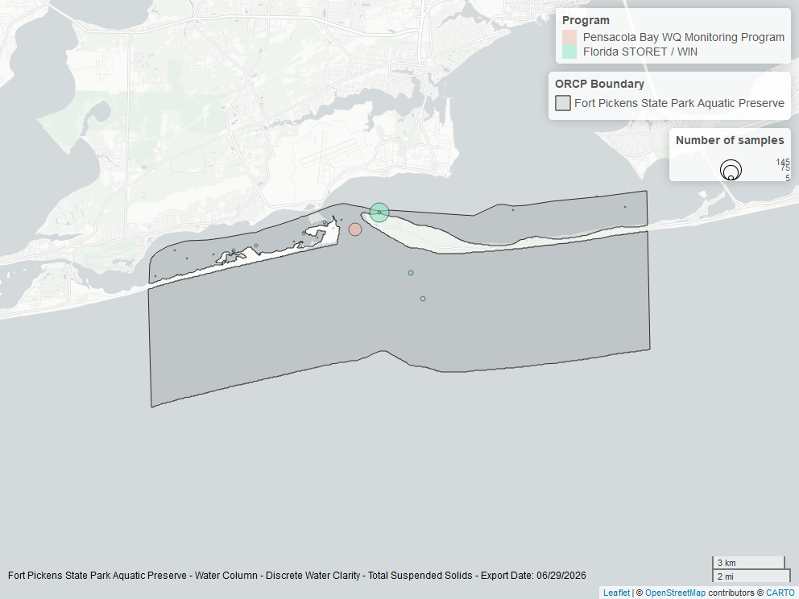

Map showing location of discrete water quality sampling locations within the boundaries of *Fort Pickens State Park Aquatic Preserve*. The bubble size on the maps above reflect the amount of data available at each sampling site.

### Chlorophyll a, Uncorrected for Pheophytin - Discrete

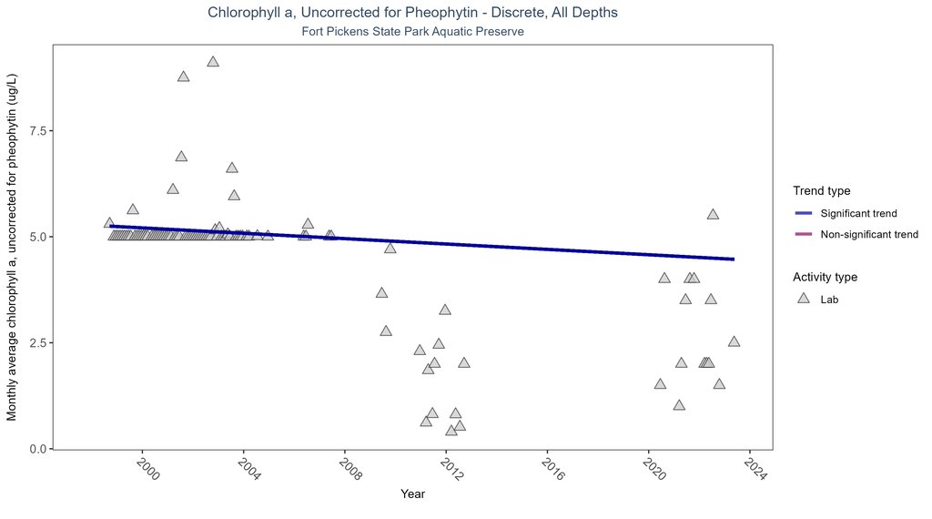

Scatter plot of monthly average levels of chlorophyll a, uncorrected for pheophytin, over time. If the time series included ten or more years of discrete observations, a significant (blue) or non-significant (magenta) trend line is also shown. Only laboratory-analyzed chlorophyll a (triangles) is included in the plot.

Table:

Monthly average chlorophyll a, uncorrected for pheophytin, decreased by 0.03 µg/L per year, indicating an increase in water clarity.

| Activity Type | Statistical Trend | Sample Count | Years with Data | Period of Record | Median Result Value | Tau | Sen Intercept | Sen Slope | P |
| --- | --- | --- | --- | --- | --- | --- | --- | --- | --- |
| Lab | Decreasing trend | 224 | 17 | 1998 - 2023 | 5 | -0.32141 | 5.27153 | -0.03167 | 0 |

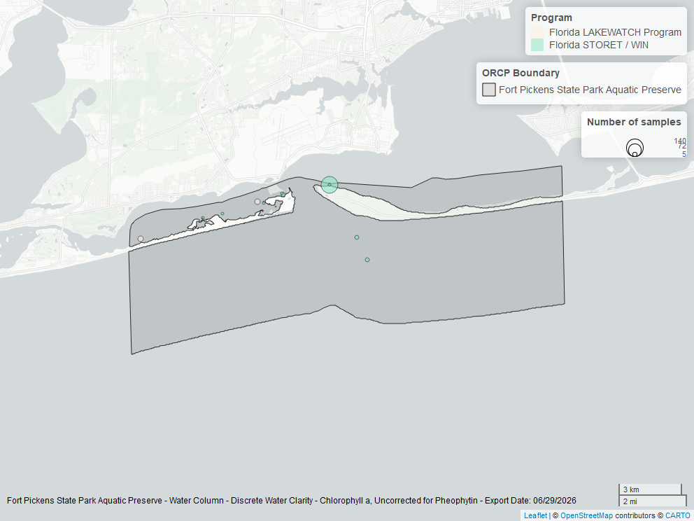

Map showing location of discrete water quality sampling locations within the boundaries of *Fort Pickens State Park Aquatic Preserve*. The bubble size on the maps above reflect the amount of data available at each sampling site.